# Cytokinin and Auxin In Apical Dominance

Alex Lee and Katie Jensen

April 24, 2017

## Introduction

1.) In plants, apical dominance occurs when auxin (a hormone that acidifies cell walls by causing cells to pump hydrogen atoms into the cell wall) travels rootward down the stalk, inhibiting axillary branching from occurring. This is an indirect influence via secondary messengers. Auxin downregulates cytokinin (CK), a hormone that increases bud growth. When a plant is decapitated, the auxin source is removed and bud growth and expression of Isopentenyl transferase (IPT) - an enzyme involved in prenylation of adenines as cytokinins - are more likely to increase.

Researchers have previously studied the interactions between auxin and cytokinin hormone signalling pathways in the *Arabidopsis thaliana* plant. Analyses found very few differentially expressed genes. We will analyze the same data and determine if we have obtained comparable results.

2.) Specifically, we would like to know if there are more or less genes that are differentially expressed than previously found. Once we have an answer to our question, we will discuss our findings.

3.)

###### Hypothesis:

We will find the same number of genes that are differentially expressed between the B and E group if we run analyses at a .05 level.

4.) The data we will be using is from the *Arabidopsis thaliana* plant and obtained from NCBI GEO: https://www.ncbi.nlm.nih.gov/geo/query/acc.cgi?acc=GSE59741. The basis for our exploratory analyses is a research paper, “Cytokinin is required for escape but not release from auxin mediated apical dominance” (Muller et al, 2015). Although a hypothesis was not clearly stated, the portion of the research paper that is of interest to us is located in the *Identification of auxin- and CK-responsive genes in buds* section.

Two sets of variables were tested. One was Auxin-treated (A) vs Ethanol Control (E) which we will refer to as the AvE group. The other was basal CK-treated plus Auxin-treated (B) vs Auxin-treated (A) control which we will refer to as the BvA group. A microarray study was conducted to compare the results of B with E (Diff) and a linear fitted model was used. At a .05 adjusted p-value, only 2 genes were found to be significantly differentially expressed. At1g7540 (codes for cytokinin oxidase), and At2g33830 (associated with bud dormancy) were more highly expressed in the B group than in the E group.

Additionally, genes with a fold-change of two or less in the E group but with a fold-change of two or more in the B group were determined to be significantly differentially expressed.

#### Anaylisis & Results

1.) We will be using R to conduct the lmfit method used by Muller et al (2015).

2.)

To begin the markdown the libraries for Limma and Affy needs to be loaded.

```r
library(limma)
library(affy)
```

##### a.)

First, we used a text file and organized the data:

```r
pd = read.AnnotatedDataFrame("sample.txt",header=TRUE,sep=",",row.names=1)
mydata = ReadAffy(filenames=pd$filename,phenoData=pd,verbose = TRUE)
```

```
## 1 reading GSM1445577_EtOH.CEL.gz ...instantiating an AffyBatch (intensity a 506944x9 matrix)...done.
## Reading in : GSM1445577_EtOH.CEL.gz
## Reading in : GSM1445578_EtOH_2_.CEL.gz
## Reading in : GSM1445579_EtOH_3_.CEL.gz
## Reading in : GSM1445580_IAA.CEL.gz
## Reading in : GSM1445581_IAA_2_.CEL.gz
## Reading in : GSM1445582_IAA_3_.CEL.gz
## Reading in : GSM1445583_IAA_+_CK.CEL.gz
## Reading in : GSM1445584_IAA_+_CK_2_.CEL.gz
## Reading in : GSM1445585_IAA_+_CK_3_.CEL.gz
```

```r
sampleNames(mydata)=row.names(pData(pd))
eset = rma(mydata)
```

```
## Background correcting
## Normalizing
## Calculating Expression
```

```r
expression_data = exprs(eset)

TS = factor(pd$treatment, levels = c("E","A", "B"))

exp_design = model.matrix(~ 0 +TS)
colnames(exp_design)=levels(TS)
```

##### b.)

Then we created a linear fit model of the expression data, compared the treatments to each other, created a matrix of the compared data, and applied empirical Bayes statitistics to the data:

```r
fit=lmFit(eset,exp_design)

contMatrix= makeContrasts(AvE=A-E, BvA=B-A, Diff= (B-A) - (E-A), levels= exp_design)

fit2 = contrasts.fit(fit, contMatrix)

diff_exp = eBayes(fit2)
```

##### c.)

Here, we set up a Venn diagram to view the differentially expressed genes at a .05 p-value:

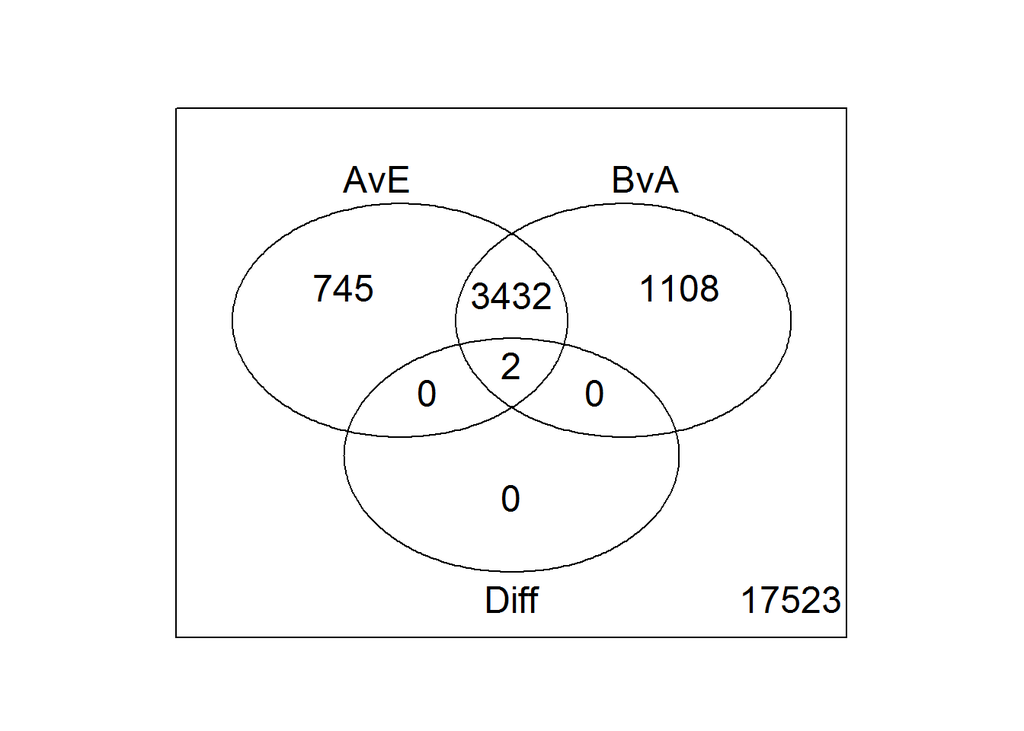

```r
result = decideTests(diff_exp, p.value = 0.05)
vennDiagram(result)
```

This shows there are two differentially expressed genes between B and E.

##### d.)

```r
f = "ftp://ftp.arabidopsis.org/Microarrays/Affymetrix/affy_ATH1_array_elements-2010-12-20.txt"
annots = read.delim(f, na.strings ="", fill=TRUE, header = T, sep="\t")
annots = annots[,c(1,5,6)]


N = dim(eset)[1]
top.A.AvE = toptable(diff_exp, coef=1, number = N, p.value = 0.05)
top.B.BvA = toptable(diff_exp, coef=2, number = N, p.value = 0.05)
top.Diff = toptable(diff_exp, coef = 3, number = N, p.value = 0.05)

#shows the gene names of compared treatments.
row.names(annots) = annots$array_element_name
top.B.BvA.merged = merge(annots, top.B.BvA, by = "row.names")
top.A.AvE.merged = merge(annots, top.A.AvE, by = "row.names")
top.Diff.merged = merge(annots, top.Diff, by = "row.names")
```

##### e.)

```r
genes.B.BvA = unique(top.B.BvA.merged$locus)
genes.Diff = unique(top.Diff.merged$locus)
genes.A.AvE = unique(top.A.AvE.merged$locus)

#shows the log fold changes of each compared treatment
logFC = top.Diff.merged[,'logFC']
logFC_AvE = top.A.AvE.merged[,'logFC']
logFC_BvE = top.B.BvA.merged[,'logFC']
```

#### Limitations

The biggest limitations in this study are that more comparisons were not made and the p-value could be considered negligible.

Since cytokinin plus auxin was compared with a simple ethanol-treated group, it only makes sense that cytokinin-responsive genes and bud dormancy genes would be differentially expressed. Comparisons among and between other treatment types should be made to truly understand the implications of an auxin-cytokinin pathway in the context of apical dominance.

Additionally, a lower p-value, such as that of .01 or even .001 could lead to a better understanding of the genes that are truly differentially expressed in relation to auxin-cytokinin in apical dominance.

#### Discussion

A cytokinin treatment alone should have been added to the variables in order to understand the true difference between cytokinin and auxin. Further studies could then be conducted to compare a cytokinin vs auxin group with a cytokinin vs ethanol group. Those relationships could be further tested against the original variables that we reviewed in this study.

#### Works Cited

MÃ¼ller, D., Waldie, T., Miyawaki, K., To, J. P., Melnyk, C. W., Kieber, J. J., Kakimoto, T., … Leyser, O. (January 01, 2015). Cytokinin is required for escape but not release from auxin mediated apical dominance. The Plant Journal : for Cell and Molecular Biology, 82, 5, 874-86